# SafeDrive Analysis

Nanda kishore Mandadapu - WIN : 574822478 , Sai Jyothi Bhumireddy- WIN: 361648962

2023-04-09

### Motivation and goal

The goal of this project was to analyze a dataset of road accidents in the Michigan , United States and identify the factors that are most impactful in causing accidents. The motivation for this project is to better understand the causes of road accidents and to develop tools and strategies to prevent them in the future.

### Aim

The project aims to answer several questions, such as: 1. What are the primary causes of road accidents? 2. Which variables have the most significant impact on the occurrence of accidents? 3. How can we predict the likelihood of an accident given certain factors such as weather conditions, road type, time of day, etc.? 4. What steps can be taken to reduce the number of accidents on the roads?

By answering these questions, we hope to gain insights into the root causes of accidents and to identify the most effective strategies for improving road safety. This project has the potential to benefit individuals, communities, and governments by reducing the number of accidents, injuries, and fatalities on the roads.

### Overview

The significant variables identified through the analysis can be used to develop targeted interventions and policies to reduce the occurrence of road accidents. For example, if speeding is found to be a significant factor, then increased enforcement of speed limits or the use of speed cameras can be implemented to reduce the number of accidents caused by speeding. Overall, the project aimed to provide insights into the causes of road accidents and to identify actionable strategies to prevent them.

### Data description

The dataset considered for this project is the “Michigan Accident’s” dataset. It is a publicly available dataset that contains information about traffic accidents that occurred in the Michigan.The dataset is quite comprehensive and provides a wealth of information for analysis. However, it also requires significant cleaning and preprocessing before it can be used effectively for data analysis.

reading the data

```r
crash_data <- read.csv("crash_data.csv", stringsAsFactors = FALSE)
```

### Cleaning

```r
# View the structure of the dataset
#str(crash_data)
# View summary statistics for the dataset
#summary(crash_data)

sum(!complete.cases(crash_data))
```

```
## [1] 80528
```

```r
# Remove rows with missing values
#crash_data <- na.omit(crash_data)

#library(impute)

# Select numeric columns
#num_cols <- sapply(crash_data, is.numeric)

# Replace NAs with mean values
#crash_data[num_cols] <- impute.mean(crash_data[num_cols])


# Convert character variables to factors
crash_data$prty_type <- as.factor(crash_data$prty_type)
crash_data$rte_no <- as.factor(crash_data$rte_no)
crash_data$milt_time <- as.factor(crash_data$milt_time)
crash_data$gndr_cd <- as.factor(crash_data$gndr_cd)

# Convert numeric variables to appropriate data type
crash_data$injy_svty_cd <- as.integer(crash_data$injy_svty_cd)
crash_data$unit_num <- as.integer(crash_data$unit_num)
crash_data$invl_prty_key <- as.integer(crash_data$invl_prty_key)
crash_data$rdwy_area_cd <- as.integer(crash_data$rdwy_area_cd)
crash_data$objectid <- as.integer(crash_data$objectid)
crash_data$pr <- as.integer(crash_data$pr)
crash_data$num_unit <- as.integer(crash_data$num_unit)
crash_data$crsh_type_cd <- as.integer(crash_data$crsh_type_cd)
crash_data$wthr_cd <- as.integer(crash_data$wthr_cd)
crash_data$lit_cd <- as.integer(crash_data$lit_cd)
crash_data$rd_cond_cd <- as.integer(crash_data$rd_cond_cd)
crash_data$num_lns <- as.integer(crash_data$num_lns)
crash_data$spd_limt <- as.integer(crash_data$spd_limt)
crash_data$mdot_regn_cd <- as.integer(crash_data$mdot_regn_cd)
crash_data$lane_dprt_cd <- as.integer(crash_data$lane_dprt_cd)
crash_data$vehc_yr <- as.integer(crash_data$vehc_yr)
crash_data$vehc_dfct_cd <- as.integer(crash_data$vehc_dfct_cd)
crash_data$prty_age <- as.integer(crash_data$prty_age)
crash_data$rstr_not_used_fail <- as.integer(crash_data$rstr_not_used_fail)
crash_data$hzrd_actn_cd <- as.integer(crash_data$hzrd_actn_cd)
crash_data$alch_susp_ind <- as.integer(crash_data$alch_susp_ind)
crash_data$drug_susp_ind <- as.integer(crash_data$drug_susp_ind)
crash_data$year <- as.integer(crash_data$year)
crash_data$traffic_volume <- as.integer(crash_data$traffic_volume)


# Create age group categories
age_categories <- cut(crash_data$prty_age, breaks = c(0, 15, 25, 35, 45, 55, 65, 120),
                      labels = c("0-15", "16-25", "26-35", "36-45", "46-55", "56-65", "65+"))

# Add the age categories as a new column to the dataset
crash_data$age_group <- age_categories

# Create a new column combining drug_susp_ind and alch_susp_ind
crash_data$drug_alcohol_suspicion <- ifelse(crash_data$drug_susp_ind == 1 | crash_data$alch_susp_ind == 1, "NO", "YES")
crash_data$drug_alcohol_suspicion<-as.factor(crash_data$drug_alcohol_suspicion)
write.csv(crash_data, file="df.csv", row.names=FALSE)
head(crash_data)
```

```
##   injy_svty_cd crsh_id unit_num invl_prty_key prty_type rdwy_area_cd objectid
## 1            5 7497108        2       3418304         D            2     4959
## 2            5 7497108        1       3418303         D            2     4959
## 3           NA 7497147        2       3418424         D            6     1098
## 4            5 7497147        1       3418421         D            6     1098
## 5           NA 7497152        2       3418441         D            6      189
## 6            5 7497152        1       3418440         D            6      189
##   rte_no      pr     mp milt_time num_unit crsh_type_cd wthr_cd lit_cd
## 1   M-47  769506  1.528       218        2            8       5      5
## 2   M-47  769506  1.528       218        2            8       5      5
## 3   I-94   14903  7.908       120        2           11       5      4
## 4   I-94   14903  7.908       120        2           11       5      4
## 5   I-94 1576405 18.424      1542        2            8       1      1
## 6   I-94 1576405 18.424      1542        2            8       1      1
##   rd_cond_cd num_lns spd_limt mdot_regn_cd lane_dprt_cd vehc_yr vehc_dfct_cd
```

[output cut: 20 more lines]

> Exploratory data analysis

## Plots

### Univariant analysis

these below plots will help us understand how / what particular kinds / reasons contribute more number of accidents

```r
# load the required libraries
library(dplyr)
```

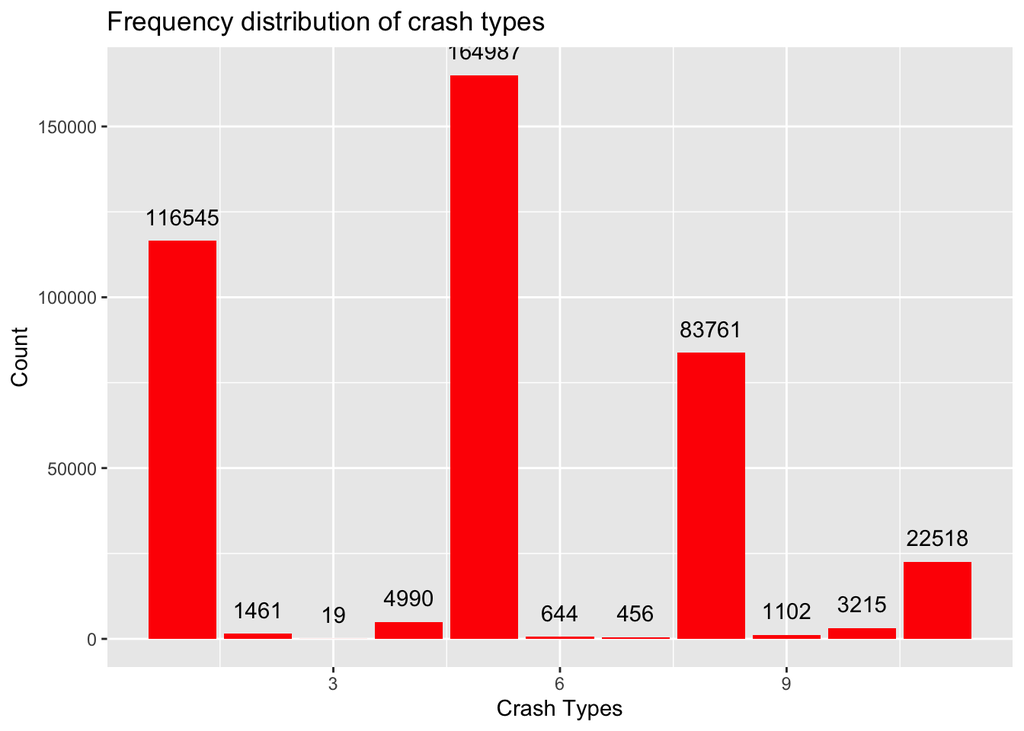

```r
library(cluster)
library(ggplot2)


df <- crash_data[complete.cases(crash_data["crsh_type_cd"]), ]

# Frequency distribution of crash types
ggplot(df, aes(x = crsh_type_cd)) +
  geom_bar(fill = "red") +
   stat_count(geom = "text", aes(label=..count..), vjust=-1) +
  labs(title = "Frequency distribution of crash types", x = "Crash Types", y = "Count")
```

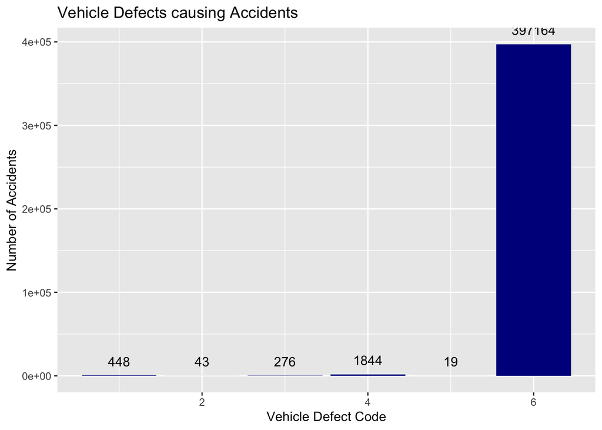

```r
# Vehicle Defects causing Accidents

df <- crash_data[complete.cases(crash_data["vehc_dfct_cd"]), ]
df %>%
  group_by(vehc_dfct_cd) %>%
  summarise(count = n()) %>%
  ggplot(aes(x = vehc_dfct_cd, y = count)) +
  geom_bar(stat = "identity", fill = "darkblue") +
  geom_text(stat='identity', aes(label=count), vjust=-1) +
  labs(title = "Vehicle Defects causing Accidents", x = "Vehicle Defect Code", y = "Number of Accidents")
```

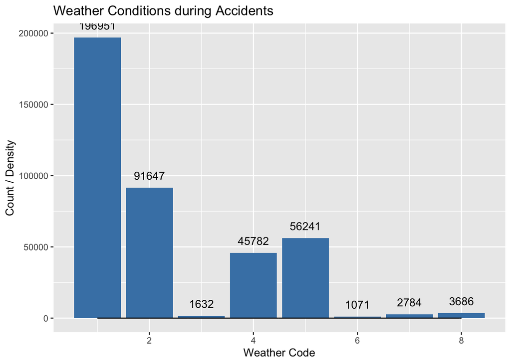

```r
# Weather conditions causing Accidents
df <- crash_data[complete.cases(crash_data["wthr_cd"]), ]
df %>%
  group_by(wthr_cd) %>%
  summarise(count = n()) %>%
  ggplot(aes(x = wthr_cd, y = count)) +
  geom_bar(stat = "identity", fill = "steelblue") +
  geom_text(stat='identity', aes(label=count), vjust=-1) +
  geom_density(aes(y = ..density..), fill = "lightblue", alpha = 0.5) +
  labs(title = "Weather Conditions during Accidents", x = "Weather Code", y = "Count / Density")
```

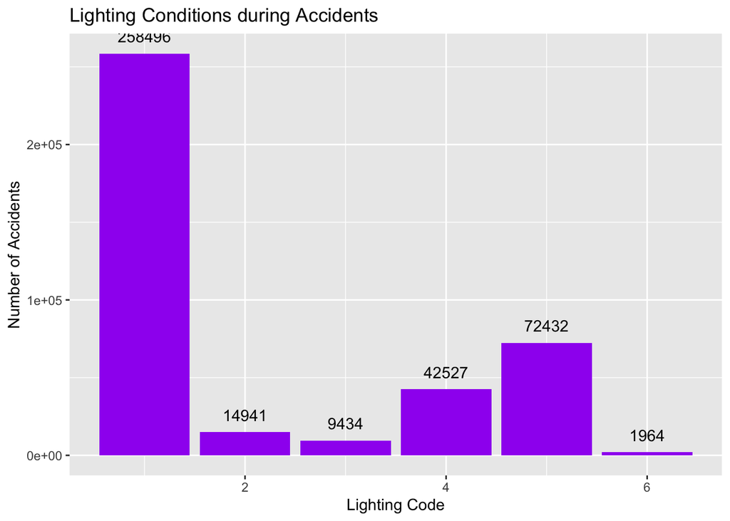

```r
# Light conditions causing Accidents
df <- crash_data[complete.cases(crash_data["lit_cd"]), ]
df %>%
  group_by(lit_cd) %>%
  summarise(count = n()) %>%
  ggplot(aes(x = lit_cd, y = count)) +
  geom_bar(stat = "identity", fill = "purple") +
  geom_text(stat='identity', aes(label=count), vjust=-1) +
  labs(title = "Lighting Conditions during Accidents", x = "Lighting Code", y = "Number of Accidents")
```

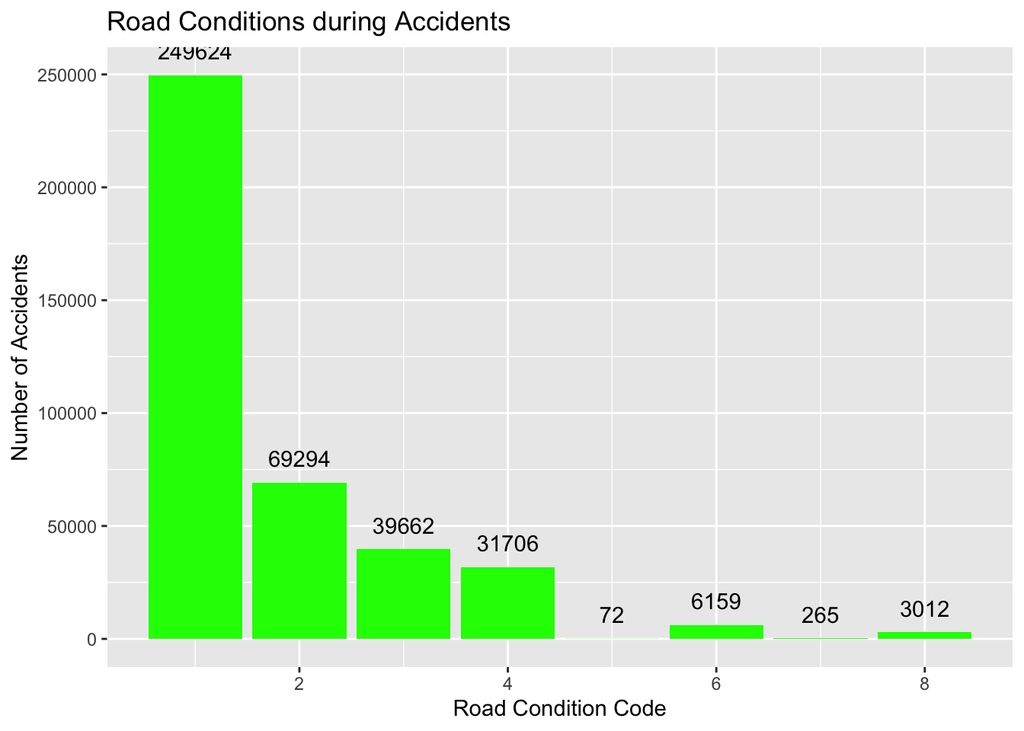

```r
# Road conditions causing Accidents
df <- crash_data[complete.cases(crash_data["rd_cond_cd"]), ]
df %>%
  group_by(rd_cond_cd) %>%
  summarise(count = n()) %>%
  ggplot(aes(x = rd_cond_cd, y = count)) +
  geom_bar(stat = "identity", fill = "green") +
  geom_text(stat='identity', aes(label=count), vjust=-1) +
  labs(title = "Road Conditions during Accidents", x = "Road Condition Code", y = "Number of Accidents")
```

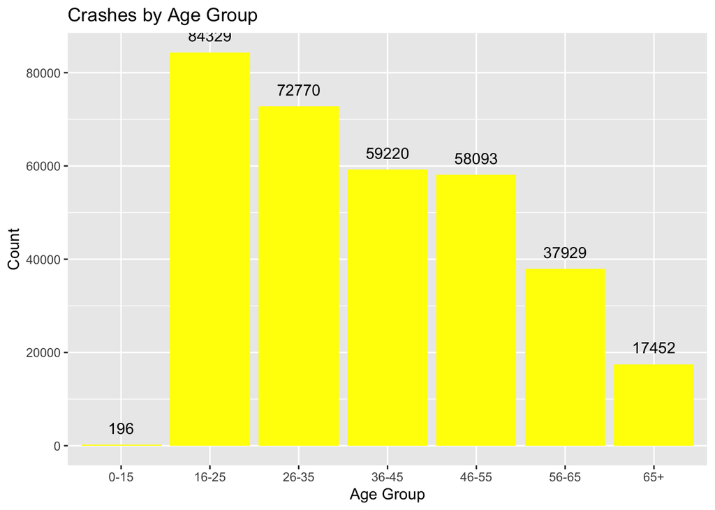

```r
# age groups

library(ggplot2)

# Create the bar chart
df <- crash_data[complete.cases(crash_data["age_group"]), ]
ggplot(df, aes(x = age_group)) +
  geom_bar(fill = "yellow") +
  stat_count(geom = "text", aes(label=..count..), vjust=-1) +
  labs(title = "Crashes by Age Group", x = "Age Group", y = "Count")
```

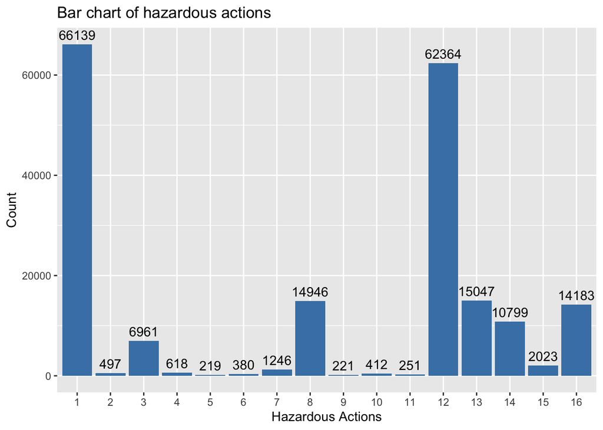

```r
# Bar chart of hazardous actions
df <- crash_data[complete.cases(crash_data["hzrd_actn_cd"]), ]
ggplot(df[df$hzrd_actn_cd != 0,], aes(x = factor(hzrd_actn_cd))) +
  geom_bar(fill = "steelblue") +
  geom_text(stat='count', aes(label=..count..), vjust=-0.5) +
  scale_x_discrete(limits=c(levels(factor(df$hzrd_actn_cd)))[-1]) +
  labs(title = "Bar chart of hazardous actions", x = "Hazardous Actions", y = "Count")
```

### Bivariant bivariant analysis will help us to understand the how well each factor contribute to severity of the injuries and is there a significant changes in means of particular factor while considering the other

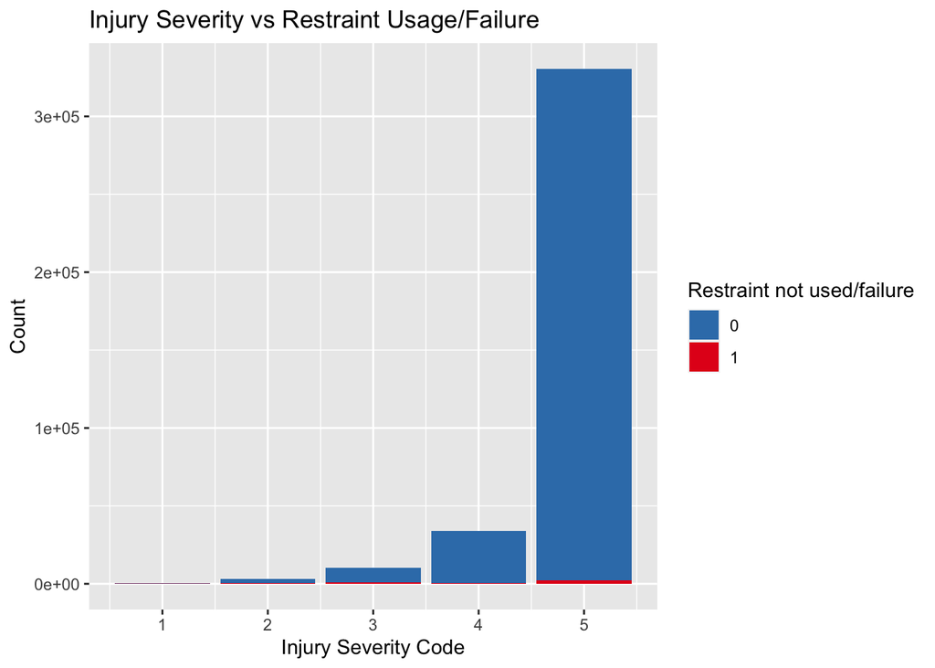

```r
library(ggplot2)
df <- crash_data[complete.cases(crash_data[c("injy_svty_cd", "rstr_not_used_fail")]), ]
ggplot(data = df, aes(x = injy_svty_cd, fill = as.factor(rstr_not_used_fail))) +
  geom_bar(position = "stack") +
  scale_fill_manual(values = c("#377EB8", "#E41A1C"), name = "Restraint not used/failure") +
  labs(title = "Injury Severity vs Restraint Usage/Failure",
       x = "Injury Severity Code", y = "Count")
```

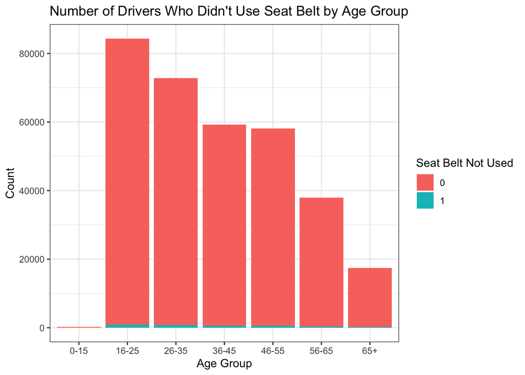

```r
library(ggplot2)
df <- crash_data[complete.cases(crash_data[c("age_group", "rstr_not_used_fail")]), ]
# create a subset of the data with the necessary columns
age_rstr <- subset(df, select = c("age_group", "rstr_not_used_fail"))

# count the number of occurrences of each combination of age_group and rstr_not_used_fail
age_rstr_count <- count(age_rstr, age_group, rstr_not_used_fail)

# create a stacked bar chart
ggplot(age_rstr_count, aes(x = age_group, y = n, fill = as.factor(rstr_not_used_fail))) +
  geom_bar(stat = "identity") +
  labs(title = "Number of Drivers Who Didn't Use Seat Belt by Age Group",
       x = "Age Group", y = "Count",
       fill = "Seat Belt Not Used") +
  theme_bw()
```

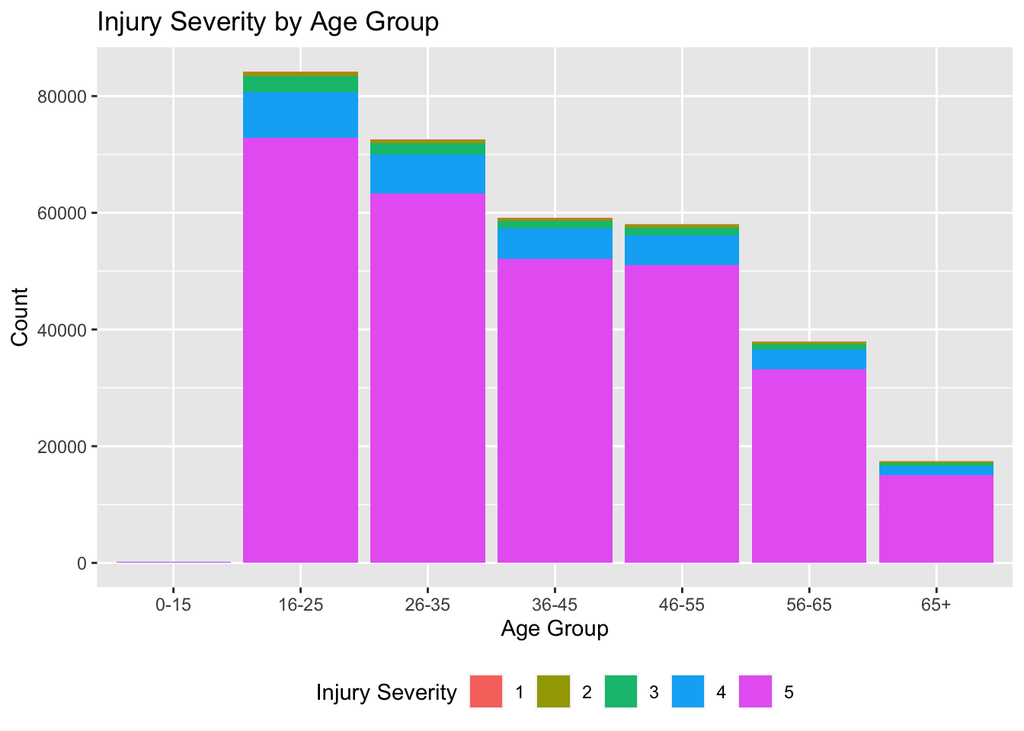

```r
df <- crash_data[complete.cases(crash_data[c("age_group", "injy_svty_cd")]), ]
ggplot(df, aes(x = as.factor(age_group), fill =as.factor(injy_svty_cd) )) +
  geom_bar(position = "stack") +
  labs(title = "Injury Severity by Age Group", x = "Age Group", y = "Count", fill = "Injury Severity") +
  theme(legend.position = "bottom")
```

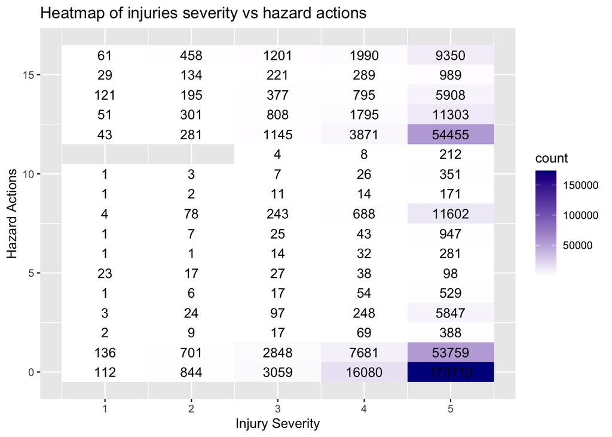

```r
library(ggplot2)
library(dplyr)
df <- crash_data[complete.cases(crash_data[c("hzrd_actn_cd", "injy_svty_cd")]), ]
# create a new dataframe with counts
df_counts <- df %>%
  group_by(injy_svty_cd, hzrd_actn_cd) %>%
  summarize(count = n(), .groups = 'drop')


# create a heatmap using ggplot2 and geom_tile()
ggplot(df_counts, aes(x = injy_svty_cd, y = hzrd_actn_cd, fill = count)) +
  geom_tile() +
  scale_fill_gradient(low = "white", high = "darkblue") +
  geom_text(aes(label = count), color = "black")+
  labs(title = "Heatmap of injuries severity vs hazard actions", x = "Injury Severity", y = "Hazard Actions")
```

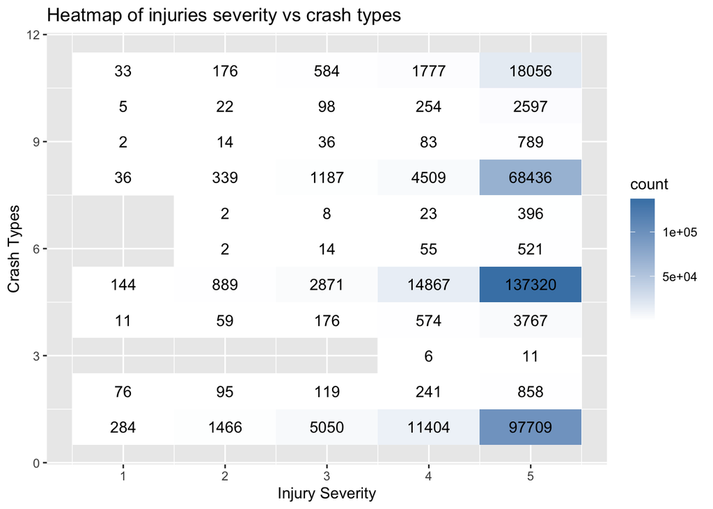

```r
df <- crash_data[complete.cases(crash_data[c("crsh_type_cd", "injy_svty_cd")]), ]
# create a new dataframe with counts
df_counts <- df %>%
  group_by(injy_svty_cd, crsh_type_cd) %>%
  summarize(count = n(), .groups = 'drop')


# create a heatmap using ggplot2 and geom_tile()
ggplot(df_counts, aes(x = injy_svty_cd, y = crsh_type_cd, fill = count)) +
  geom_tile() +
  scale_fill_gradient(low = "white", high = "steelblue") +
  geom_text(aes(label = count), color = "black")+
  labs(title = "Heatmap of injuries severity vs crash types", x = "Injury Severity", y = "Crash Types")
```

### Multivarient

to understand the relation between group of binary / factors that implying the injury severity

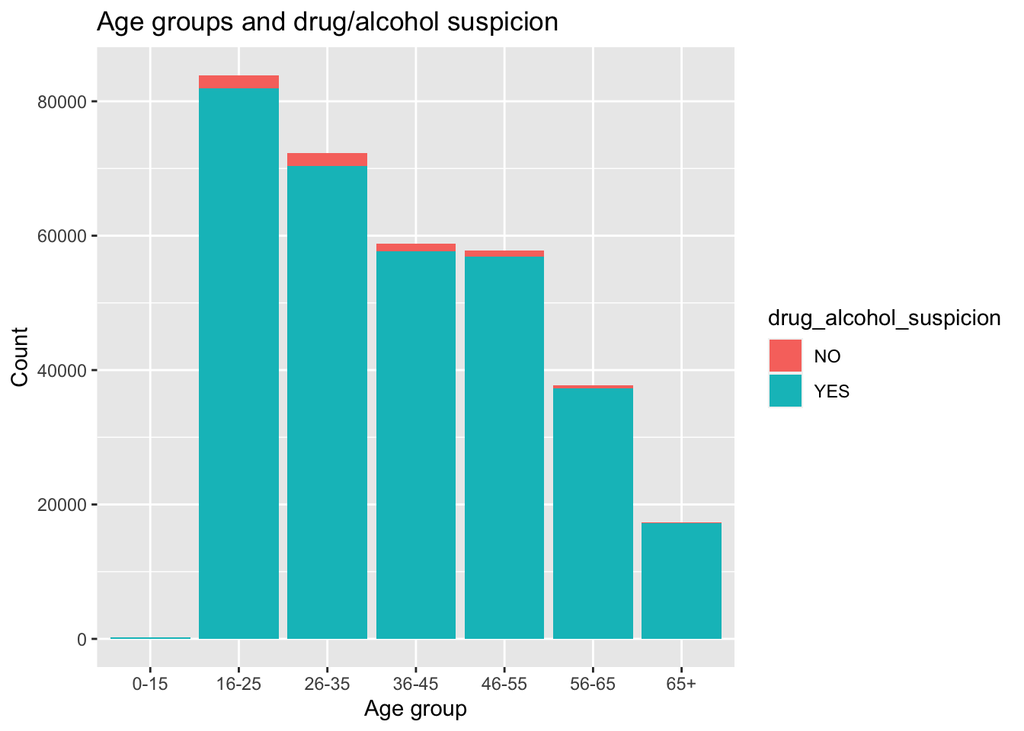

```r
library(ggplot2)
df <- crash_data[complete.cases(crash_data[c("age_group", "drug_alcohol_suspicion", "injy_svty_cd")]), ]
# Age group and drug/alcohol suspicion
ggplot(df, aes(x = age_group, fill = drug_alcohol_suspicion)) +
  geom_bar() +
  labs(title = "Age groups and drug/alcohol suspicion", x = "Age group", y = "Count")
```

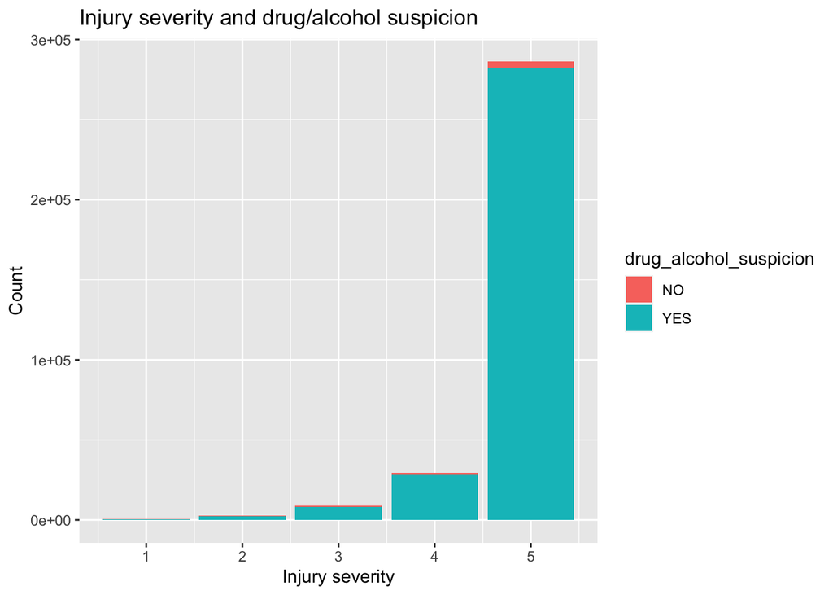

```r
# Injury severity and drug/alcohol suspicion
ggplot(df, aes(x = injy_svty_cd, fill = drug_alcohol_suspicion)) +
  geom_bar() +
  labs(title = "Injury severity and drug/alcohol suspicion", x = "Injury severity", y = "Count")
```

By asking these more specific questions, we were able to gain a more nuanced understanding of the factors contributing to road accidents and identify potential areas for intervention and prevention. Additionally, some questions were refined or even discarded based on the results of our data analysis. Overall, the questions evolved as we gained a deeper understanding of the data and the factors influencing road accidents.

### Cluster analysis of crash type, weather condition, and lighting condition

```r
library(factoextra)
```

[figure not shown]

```r
library(factoextra)

df_cluster <- df %>%
  select(crsh_type_cd, lit_cd, wthr_cd) %>%
  mutate_all(as.numeric)

df_cluster <- df_cluster[complete.cases(df_cluster),]

df_cluster_numeric <- apply(df_cluster, 2, function(x) as.numeric(as.character(x)))
df_cluster_scaled <- scale(df_cluster_numeric)

cluster_plot <- fviz_cluster(kmeans(df_cluster_scaled, 3, nstart = 25), data = df_cluster)

print(cluster_plot)
```

> Data analysis

Several statistical methods were considered for this project, including: 1. Descriptive statistics: used to summarize and describe the main features of the dataset, such as mean, median, standard deviation, and quartiles. 2. Correlation analysis: used to investigate the relationship between different variables in the dataset and to identify potential predictors of accidents. 3. Regression analysis: used to model the relationship between dependent and independent variables and to identify significant predictors of accidents.

```r
# Check the drug/alcohol usage
table(crash_data$drug_alcohol_suspicion)
```

```
##
##     NO    YES
##   7298 388428
```

```r
# Check the seatbelt usage
table(crash_data$rstr_not_used_fail)
```

```
##
##      0      1
## 395737   4057
```

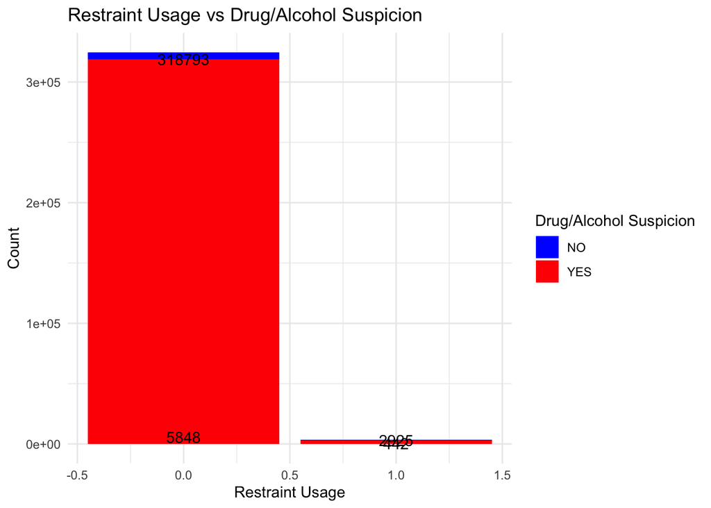

```r
library(ggplot2)

df_counts <- df %>%
  group_by(rstr_not_used_fail, drug_alcohol_suspicion) %>%
  summarize(count = n(), .groups = 'drop')


ggplot(df_counts, aes(x = rstr_not_used_fail, y = count, fill = drug_alcohol_suspicion)) +
  geom_bar(stat="identity") +
  labs(title = "Restraint Usage vs Drug/Alcohol Suspicion",
       x = "Restraint Usage", y = "Count",
       fill = "Drug/Alcohol Suspicion") +
  scale_fill_manual(values = c("blue", "red", "purple")) +
  geom_text(aes(label = count), color = "black")+
  theme_minimal()
```

### cleaning for analysis

#### data cleaning (handling the missing values and Na values)

```r
library(corrplot)
# Subset numeric columns
crash_data_numeric <- crash_data[, sapply(crash_data, is.numeric)]

sum(!complete.cases(crash_data))
```

```
## [1] 80528
```

```r
# Calculate correlation matrix
cor_matrix <- cor(crash_data_numeric, use = "pairwise.complete.obs")

# Loop through each column and fill missing values with mean of highly correlated columns
for (col in names(crash_data_numeric)) {
  if (any(is.na(crash_data_numeric[[col]]))) {
    # Find columns with non-missing values that are highly correlated to the missing column
    correlated_cols <- cor_matrix[, col, drop = FALSE]
    correlated_cols <- names(correlated_cols[!is.na(correlated_cols) & abs(correlated_cols) > 0.5])

    # If there are no highly correlated columns, replace missing values with the column mean
    if (length(correlated_cols) == 0) {
      crash_data_numeric[[col]][is.na(crash_data_numeric[[col]])] <- mean(crash_data_numeric[[col]], na.rm = TRUE)
    }
    # Otherwise, replace missing values with the mean of the highly correlated columns
    else {
      crash_data_numeric[[col]][is.na(crash_data_numeric[[col]])] <- rowMeans(crash_data_numeric[, correlated_cols], na.rm = TRUE)
    }
  }
}


# Copy the filled numeric columns back to the original dataset
crash_data[, sapply(crash_data, is.numeric)] <- crash_data_numeric

sum(!complete.cases(crash_data))
```

```
## [1] 71340
```

```r
nrow(crash_data)
```

```
## [1] 399794
```

```r
# Perform multiple linear regression to determine impactful factors
# Convert non-numeric variables into factors or numeric variables
crash_data<-na.omit(crash_data)

nrow(crash_data)
```

```
## [1] 328454
```

```r
# Remove duplicates
crash_data_uni<- unique(crash_data)
crash_data_uni<-na.omit(crash_data_uni)
nrow(crash_data_uni)
```

```
## [1] 325959
```

### Correlation Analysis

to find the significant causes of injuries

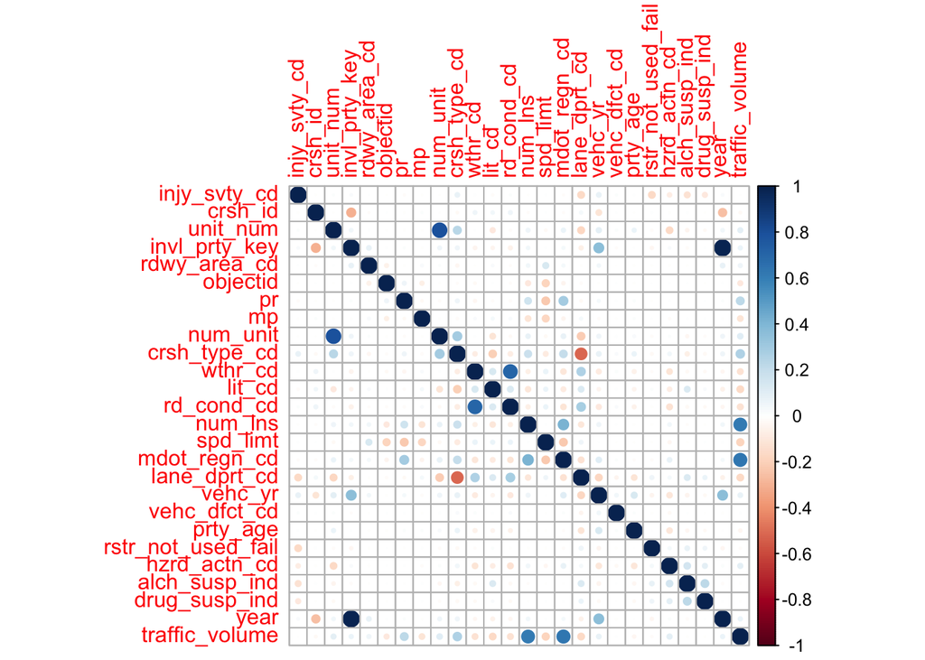

```r
corr_df <- crash_data_uni%>%
  select_if(is.numeric) %>%
  cor()
corrplot::corrplot(corr_df, method = "circle")
```

```r
corr_target <- corr_df[1, -1]

corr_sorted <- sort(corr_target, decreasing = TRUE)

top_corr_vars <- names(corr_sorted[abs(corr_sorted) > 0.1])

top_corr_vars
```

```
## [1] "alch_susp_ind"      "rstr_not_used_fail" "lane_dprt_cd"
```

### Regression Analysis

to understand the most impactfull factors that helps to predict the injury severity

```r
# Check levels of all categorical variables
sapply(crash_data_uni, function(x) if(is.factor(x)) length(levels(x)) else NA)
```

```
##           injy_svty_cd                crsh_id               unit_num
##                     NA                     NA                     NA
##          invl_prty_key              prty_type           rdwy_area_cd
##                     NA                      1                     NA
##               objectid                 rte_no                     pr
##                     NA                     44                     NA
##                     mp              milt_time               num_unit
##                     NA                   2039                     NA
##           crsh_type_cd                wthr_cd                 lit_cd
##                     NA                     NA                     NA
##             rd_cond_cd                num_lns               spd_limt
##                     NA                     NA                     NA
##           mdot_regn_cd           lane_dprt_cd                vehc_yr
##                     NA                     NA                     NA
##           vehc_dfct_cd               prty_age     rstr_not_used_fail
##                     NA                     NA                     NA
##                gndr_cd           hzrd_actn_cd          alch_susp_ind
##                      3                     NA                     NA
##          drug_susp_ind                   year         traffic_volume
##                     NA                     NA                     NA
##              age_group drug_alcohol_suspicion
##                      7                      2
```

```r
# Select the columns to be used in the regression
columns <- c("injy_svty_cd", "crsh_type_cd", "wthr_cd", "lit_cd", "rd_cond_cd", "num_lns", "spd_limt", "vehc_yr", "vehc_dfct_cd", "rstr_not_used_fail", "gndr_cd", "hzrd_actn_cd", "year", "traffic_volume", "age_group", "drug_alcohol_suspicion")

# Create a new dataframe with only the selected columns
df_selected <- crash_data_uni[, columns]
df_selected$drug_alcohol_suspicion<-as.numeric(df_selected$drug_alcohol_suspicion)

#for(col in columns){
  #df_selected[, col] <- as.factor(df_selected[, col])
#}

#df_selected$injy_svty_cd <- as.numeric(df_selected$injy_svty_cd)
#df_selected$traffic_volume<-as.numeric(df_selected$traffic_volume)
# Check levels of all categorical variables
#sapply(df_selected, function(x) if(is.factor(x)) length(levels(x)) else NA)
# Perform multiple linear regression to determine impactful factors
model <- lm(injy_svty_cd ~ ., data = df_selected)
#summary(model) # view summary of model

# Obtain p-values for each variable in the model
p_values <- summary(model)$coefficients[, 4]

# Determine significant variables based on p-values less than 0.05
sig_vars <- names(p_values[p_values < 0.05])

sig_vars
```

```
##  [1] "(Intercept)"            "crsh_type_cd"           "rd_cond_cd"
##  [4] "num_lns"                "spd_limt"               "vehc_yr"
##  [7] "vehc_dfct_cd"           "rstr_not_used_fail"     "hzrd_actn_cd"
## [10] "year"                   "traffic_volume"         "drug_alcohol_suspicion"
```

#### chi-squared test

```r
#wthr_cd chi-squared test
chi_square_result_wthr_cd <- chisq.test(df_selected$wthr_cd, df_selected$injy_svty_cd)
print(chi_square_result_wthr_cd)
```

```
##
##  Pearson's Chi-squared test
##
## data:  df_selected$wthr_cd and df_selected$injy_svty_cd
## X-squared = 402.96, df = 35, p-value < 2.2e-16
```

```r
#lit_cd chi-squared test
chi_square_result_lit_cd <- chisq.test(df_selected$lit_cd, df_selected$injy_svty_cd)
print(chi_square_result_lit_cd)
```

```
##
##  Pearson's Chi-squared test
##
## data:  df_selected$lit_cd and df_selected$injy_svty_cd
## X-squared = 1243, df = 25, p-value < 2.2e-16
```

#### t-test

to check weather the change in gender will impose any change in mean values of the hazardous actions the person do

```r
# For example, conducting t-tests to compare hzrd_actn_cd between different groups
df <- crash_data[complete.cases(crash_data["hzrd_actn_cd"]), ]
df_selected$hzrd_actn_cd<-as.numeric(df_selected$hzrd_actn_cd)
t.test(df_selected$hzrd_actn_cd[df_selected$gndr_cd == "F"], df_selected$hzrd_actn_cd[df$gndr_cd == "M"])
```

```
##
##  Welch Two Sample t-test
##
## data:  df_selected$hzrd_actn_cd[df_selected$gndr_cd == "F"] and df_selected$hzrd_actn_cd[df$gndr_cd == "M"]
## t = -10.294, df = 272224, p-value < 2.2e-16
## alternative hypothesis: true difference in means is not equal to 0
## 95 percent confidence interval:
##  -0.2416947 -0.1643780
## sample estimates:
## mean of x mean of y
##  3.621783  3.824819
```

#### Related Work for reference

1. “Analysis of Road Traffic Accidents in Nigeria: A Case Study of Obinze/Nekede/Ihiagwa Road in Imo State” by Christian I. Nwachukwu and Rita A. Anyanwu. This paper analyzes road traffic accidents in Nigeria using statistical methods and identifies factors that contribute to the accidents.
2. “Data Mining Techniques in Accident Data Analysis” by Zuhair Almusawi and David W. Jones. This paper discusses the use of data mining techniques, including decision trees, to analyze accident data and identify factors that contribute to accidents.
3. “Traffic Accident Analysis using Decision Tree and Association Rule Mining” by Jaeseok Jeong and Daeho Lee. This paper uses decision trees and association rule mining to analyze traffic accident data and identify factors that contribute to accidents.
4. “Road Accident Analysis and Prediction Using Data Mining Techniques” by Rupali Sharma and Dr. Deepak Garg. This paper uses data mining techniques, including decision trees, to analyze road accident data and predict the likelihood of accidents.
5. “Statistical Analysis of Road Accidents in India” by Aditi Gupta and Ruchika Gupta. This paper analyzes road accident data in India using statistical methods and identifies factors that contribute to the accidents.
6. “Accident Analysis and Prediction Model Development in Road Traffic Accidents” by Mehmet Yilmaz and Ali Koru. This paper develops a prediction model for road traffic accidents using statistical methods and identifies factors that contribute to the accidents.
7. “Predicting Traffic Accident Severity using Decision Tree and Random Forest Models” by Jian Zhang and Yunpeng Wang. This paper uses decision tree and random forest models to predict traffic accident severity based on various factors.
8. “Exploratory Data Analysis of Road Accidents in Nigeria” by Olaniyi O. Olayinka and Oluwasegun S. Fatumo. This paper uses exploratory data analysis to analyze road accident data in Nigeria and identify factors that contribute to the accidents.
9. “Analysis of Traffic Accident Data Using Decision Trees” by Ahmad Al-Hajj and Tamer AbuHmed. This paper uses decision trees to analyze traffic accident data and identify factors that contribute to accidents.
10. “Analysis of Road Traffic Accidents in Lebanon: Identification of Hotspots and Factors Contributing to Severity” by Rola Khamis, Hassan Hawari, and Abbas Alameddine. This paper analyzes road traffic accidents in Lebanon and identifies hotspots and factors that contribute to the severity of accidents.